# Assignment 6

In this assignment, you'll analyze a collection of data sets from the [San Francisco Open Data Portal](http://data.sfgov.org/) and [Zillow](https://www.zillow.com/). The data sets have been stored in the SQLite database `sf_data.sqlite`, which you can [download here](http://anson.ucdavis.edu/~nulle/sf_data.sqlite). The database contains the following tables:

| Table | Description |
| --- | --- |
| `crime` | Crime reports dating back to 2010. |
| `mobile_food_locations` | List of all locations where mobile food vendors sell. |
| `mobile_food_permits` | List of all mobile food vendor permits. More details [here](https://data.sfgov.org/api/views/rqzj-sfat/files/8g2f5RV4PEk0_b24iJEtgEet9gnh_eA27GlqoOjjK4k?download=true&filename=DPW_DataDictionary_Mobil… |
| `mobile_food_schedule` | Schedules for mobile food vendors. |
| `noise` | Noise complaints dating back to August 2015. |
| `parking` | List of all parking lots. |
| `parks` | List of all parks. |
| `schools` | List of all schools. |
| `zillow` | Zillow rent and housing statistics dating back to 1996. More details [here](https://www.zillow.com/research/data/). |

The `mobile_food_` tables are explicitly connected through the `locationid` and `permit` columns. The other tables are not connected, but you may be able to connect them using dates, latitude/longitude, or postal codes.

Shapefiles for US postal codes are available [here](https://www.census.gov/geo/maps-data/data/cbf/cbf_zcta.html). These may be useful for converting latitude/longitude to postal codes.

Shapefiles for San Francisco Neighborhoods are available [here](https://data.sfgov.org/Geographic-Locations-and-Boundaries/SF-Find-Neighborhoods/pty2-tcw4).

**Exercise 1.1.** Which mobile food vendor(s) sells at the most locations?

```python
import pandas as pd
%matplotlib inline
# Make plots larger.
import matplotlib.pyplot as plt
plt.rcParams['figure.figsize'] = (12, 12)
import sqlalchemy as sqla
import sqlite3
plt.style.use('ggplot')
```

```python
sqlite_file = 'sf_data.sqlite'
conn = sqlite3.connect(sqlite_file)
```

```python
conn2 = sqla.create_engine('sqlite:///' + sqlite_file)
```

```python
conn2
```

```
Engine(sqlite:///sf_data.sqlite)
```

```python
pd.read_sql_query("select permit, count(locationid) AS places from mobile_food_schedule group by permit order by places desc",conn2).head()
```

|  | permit | places |
| --- | --- | --- |
| 0 | 17MFF-0110 | 340 |
| 1 | 13MFF-0102 | 221 |
| 2 | 17MFF-0111 | 212 |
| 3 | 17MFF-0090 | 182 |
| 4 | 14MFF-0109 | 165 |

From here we see that the top three vendors sell at 340, 221, and 212 places.

```python
pd.read_sql_query("select Applicant from mobile_food_permits where permit = '17MFF-0110' OR permit = '13MFF-0102' OR permit = '17MFF-0111'",conn2)
```

|  | Applicant |
| --- | --- |
| 0 | Natan's Catering |
| 1 | May Catering |
| 2 | Anas Goodies Catering |

These vendors are Natan's Catering, May Catering, Anas Goodies Catering.

**Exercise 1.2.** Ask and use the database to analyze 5 questions about San Francisco. For each question, write at least 150 words and support your answer with plots. Make a map for at least 2 of the 5 questions.

You should try to come up with some questions on your own, but these are examples of reasonable questions:

- Which parts of the city are the most and least expensive?
- Which parts of the city are the most dangerous (and at what times)?
- Are noise complaints and mobile food vendors related?
- What are the best times and places to find food trucks?
- Is there a relationship between housing prices and any of the other tables?

Please make sure to clearly state each of your questions in your submission.

### Question 1

Which parts of the city are the most dangerous and at what times?

```python
pd.read_sql_query("select DISTINCT CATEGORY from crime",conn2)
```

|  | Category |
| --- | --- |
| 0 | NON-CRIMINAL |
| 1 | ROBBERY |
| 2 | ASSAULT |
| 3 | SECONDARY CODES |
| 4 | VANDALISM |
| 5 | BURGLARY |
| 6 | LARCENY/THEFT |
| 7 | DRUG/NARCOTIC |
| 8 | WARRANTS |
| 9 | VEHICLE THEFT |
| 10 | OTHER OFFENSES |
| 11 | WEAPON LAWS |
| 12 | ARSON |
| 13 | MISSING PERSON |
| 14 | DRIVING UNDER THE INFLUENCE |
| 15 | SUSPICIOUS OCC |
| 16 | RECOVERED VEHICLE |
| 17 | DRUNKENNESS |
| 18 | TRESPASS |
| 19 | FRAUD |
| 20 | DISORDERLY CONDUCT |
| 21 | SEX OFFENSES, FORCIBLE |
| 22 | FORGERY/COUNTERFEITING |
| 23 | KIDNAPPING |
| 24 | EMBEZZLEMENT |
| 25 | STOLEN PROPERTY |
| 26 | LIQUOR LAWS |
| 27 | FAMILY OFFENSES |
| 28 | LOITERING |
| 29 | BAD CHECKS |
| 30 | TREA |
| 31 | GAMBLING |
| 32 | RUNAWAY |
| 33 | BRIBERY |
| 34 | PROSTITUTION |
| 35 | PORNOGRAPHY/OBSCENE MAT |
| 36 | SEX OFFENSES, NON FORCIBLE |
| 37 | SUICIDE |
| 38 | EXTORTION |

```python
pd.read_sql_query("select * from crime",conn2).head()
```

|  | IncidntNum | Category | Descript | DayOfWeek | Datetime | PdDistrict | Resolution | Address | Lon | Lat |
| --- | --- | --- | --- | --- | --- | --- | --- | --- | --- | --- |
| 0 | 150060275 | NON-CRIMINAL | LOST PROPERTY | Monday | 2015-01-19 14:00:00 | MISSION | NONE | 18TH ST / VALENCIA ST | -122.421582 | 37.761701 |
| 1 | 150098210 | ROBBERY | ROBBERY, BODILY FORCE | Sunday | 2015-02-01 15:45:00 | TENDERLOIN | NONE | 300 Block of LEAVENWORTH ST | -122.414406 | 37.784191 |
| 2 | 150098210 | ASSAULT | AGGRAVATED ASSAULT WITH BODILY FORCE | Sunday | 2015-02-01 15:45:00 | TENDERLOIN | NONE | 300 Block of LEAVENWORTH ST | -122.414406 | 37.784191 |
| 3 | 150098210 | SECONDARY CODES | DOMESTIC VIOLENCE | Sunday | 2015-02-01 15:45:00 | TENDERLOIN | NONE | 300 Block of LEAVENWORTH ST | -122.414406 | 37.784191 |
| 4 | 150098226 | VANDALISM | MALICIOUS MISCHIEF, VANDALISM OF VEHICLES | Tuesday | 2015-01-27 19:00:00 | NORTHERN | NONE | LOMBARD ST / LAGUNA ST | -122.431119 | 37.800469 |

```python
crimesByDistrict = pd.read_sql_query("select PdDistrict, count(Category) as totCrimes from crime group by PdDistrict",conn2)
```

```python
districtCrimes = crimesByDistrict[1:]
maxCrimes = max(districtCrimes.totCrimes)
minCrimes = min(districtCrimes.totCrimes)
maxDistrict = districtCrimes[districtCrimes.totCrimes == maxCrimes]
minDistrict = districtCrimes[districtCrimes.totCrimes == minCrimes]
```

```python
maxDistrict, minDistrict
```

```
(  PdDistrict  totCrimes
 8   SOUTHERN     196178,   PdDistrict  totCrimes
 7   RICHMOND      56258)
```

From here we see that the district with the most crimes is the Southern district and the district with the least crimes is Richmond.

```python
southern = pd.read_sql_query("select Category, count(Category) as occurance from crime where PdDistrict='SOUTHERN' group by Category",conn2)
```

```python
maxCrime = max(southern.occurance)
southern[southern.occurance == maxCrime]
```

|  | Category | occurance |
| --- | --- | --- |
| 16 | LARCENY/THEFT | 60068 |

From here we see that the most reoccuring crime is theft in the southern district with over 60,000 occurances since 2010.

```python
richmond = pd.read_sql_query("select Category, count(Category) as occurance from crime where PdDistrict='RICHMOND' group by Category",conn2)
```

```python
minCrime = min(richmond.occurance)
richmond[richmond.occurance == minCrime]
```

|  | Category | occurance |
| --- | --- | --- |
| 21 | PORNOGRAPHY/OBSCENE MAT | 3 |

To answer this question we first check to see how many different categories of crimes there are. We see that there are 39 categories. For this problem we will assume that all categories are considered to be dangerous to answer the question. We see that the district with the last crimes is Richmond and the crime in Richmond that occured the least is pornography. The district with the most crimes was in the southern district. The crime in the southern district that occurred the most was larcency and theft

```python
southernTime = pd.read_sql_query("select Category, Datetime, count(Datetime) as occurance from crime where PdDistrict='SOUTHERN' group by Datetime",conn2)
```

```python
from datetime import datetime
```

```python
hour = []
for i in range(0, len(southernTime)):
    date = southernTime.Datetime[i].split(" ")[1]
    date = datetime.strptime(date, '%H:%M:%S')
    hour.append(date.hour)
```

```python
df = pd.DataFrame(hour)
```

```python
df.describe()
```

|  | 0 |
| --- | --- |
| count | 128378.000000 |
| mean | 13.538683 |
| std | 6.399302 |
| min | 0.000000 |
| 25% | 9.000000 |
| 50% | 14.000000 |
| 75% | 19.000000 |
| max | 23.000000 |

```python
crimeTime = pd.read_sql_query("select Category, Datetime, count(Datetime) as occurance from crime group by Datetime",conn2)
```

```python
hour = []
for i in range(0, len(crimeTime)):
    date = crimeTime.Datetime[i].split(" ")[1]
    date = datetime.strptime(date, '%H:%M:%S')
    hour.append(date.hour)
```

```python
timedf = pd.DataFrame(hour)
```

```python
timedf.columns = ['hour']
```

```python
groups = timedf.groupby(['hour']).size()
```

```python
groups = pd.DataFrame(groups)
```

```python
groups.columns = ['count']
```

```python
times = []
for i in range(0, 24):
    times.append(groups.iloc[i])
```

```python
times = pd.DataFrame(times)
```

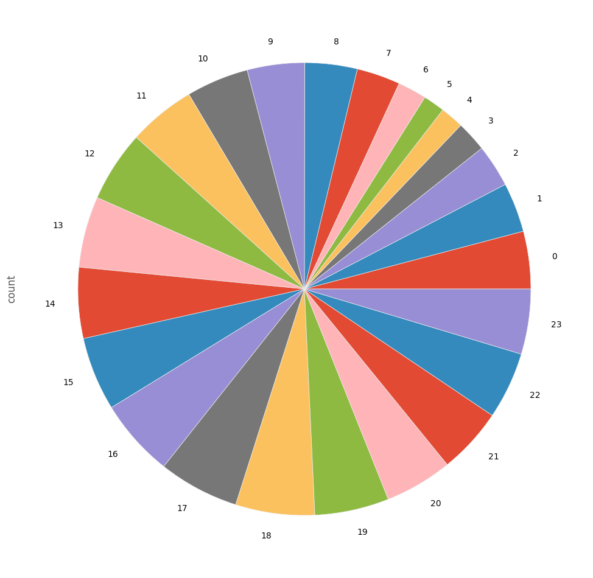

```python
times.plot(y = 'count', kind = 'pie', legend = False)
```

### Question 2

Which region is the most and least expensive?

```python
zillow = pd.read_sql_query("select  * from zillow",conn2)
```

```python
zillow.head()
```

|  | RegionName | Date | ZriPerSqft_AllHomes | MedianSoldPricePerSqft_AllHomes | PriceToRentRatio_AllHomes | Turnover_AllHomes |
| --- | --- | --- | --- | --- | --- | --- |
| 0 | 94109 | 2010-11-01 00:00:00 | 3.156 | 675.1913 | 19.14 | 6.0771 |
| 1 | 94110 | 2010-11-01 00:00:00 | 2.566 | 599.6785 | 18.10 | 5.4490 |
| 2 | 94122 | 2010-11-01 00:00:00 | 2.168 | 495.4432 | 17.99 | 2.4198 |
| 3 | 94080 | 2010-11-01 00:00:00 | 1.666 | 369.5538 | 18.31 | 3.8757 |
| 4 | 94112 | 2010-11-01 00:00:00 | 2.322 | 422.4538 | 14.44 | 3.1288 |

```python
zillow = zillow.dropna()
```

```python
priceMax = pd.read_sql_query("select RegionName, max(MedianSoldPricePerSqft_AllHomes) from zillow",conn2)
priceMin = pd.read_sql_query("select RegionName, min(MedianSoldPricePerSqft_AllHomes) from zillow",conn2)
```

```python
priceMax, priceMin
```

```
(   RegionName  max(MedianSoldPricePerSqft_AllHomes)
 0       94104                           1336.128581,
    RegionName  min(MedianSoldPricePerSqft_AllHomes)
 0       94124                               103.938)
```

Since there are many rows with NAs in this dataset, I chose to drop them so it wouldn't interfere with my analysis for maximum and minimum median price for homes. From here, we see the most expensive region is 94104 (median sold price per sqft is \$1336) and the least expensive region is 94124 (median sold price per sqft is \$103).

```python
price = pd.read_sql_query("select RegionName, max(MedianSoldPricePerSqft_AllHomes), min(MedianSoldPricePerSqft_AllHomes) from zillow group by RegionName",conn2)
```

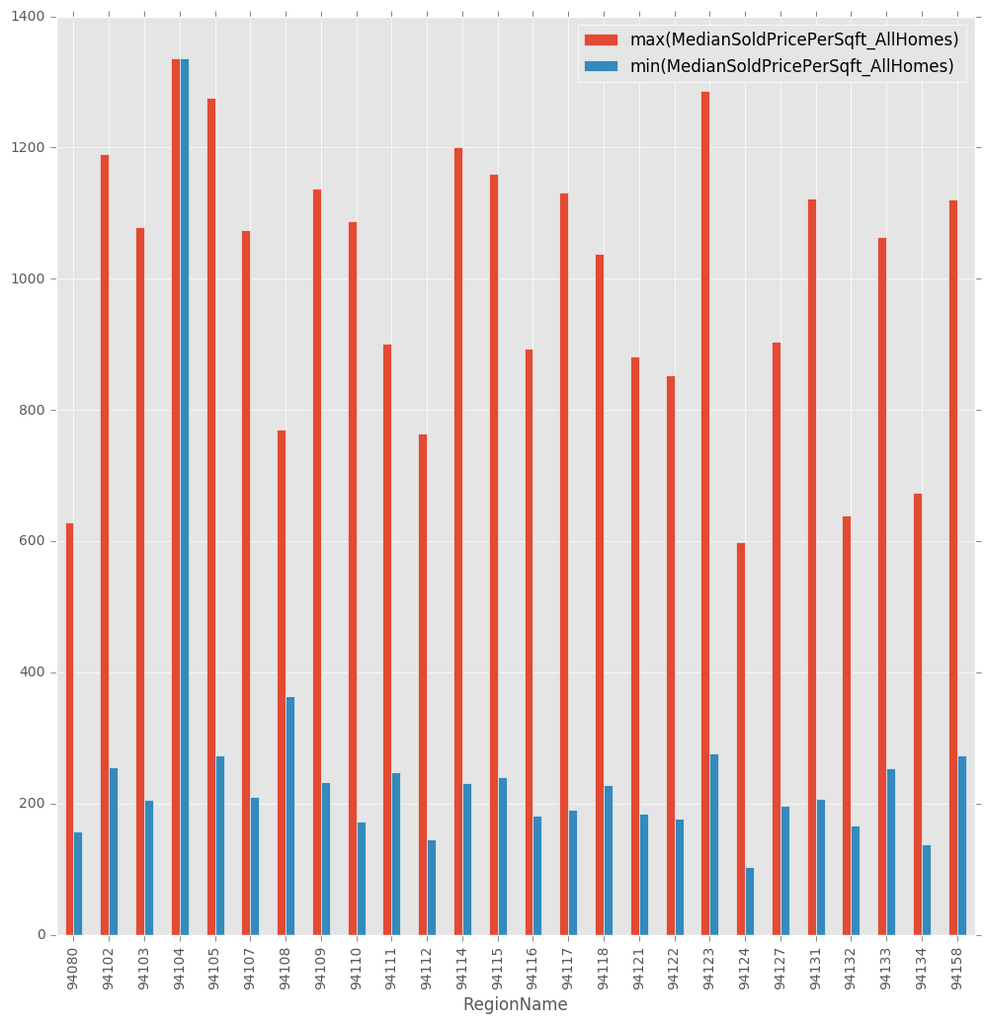

```python
price.plot(kind = 'bar', y = ['max(MedianSoldPricePerSqft_AllHomes)', 'min(MedianSoldPricePerSqft_AllHomes)'], x = 'RegionName')
```

From the plot below we see that there is a large difference between the max and min prices of homes per region. The only place that has around the same value for the max and min price is region 94104. This must be a more expensive/nice area if the min price is about equivalent to the max price.

### Question 3

Which areas are the most and least quiet.

```python
areas = pd.read_sql_query("select Neighborhood, count(neighborhood) as occurances, Lat, Lon from noise group by Neighborhood",conn2)
```

```python
areas = areas[1:len(areas)]
```

```python
areas = areas.reset_index()
```

```python
del areas['index']
```

```python
group = areas.groupby(['occurances']).size()
group = pd.DataFrame(group)
```

```python
group.columns = ['count']
```

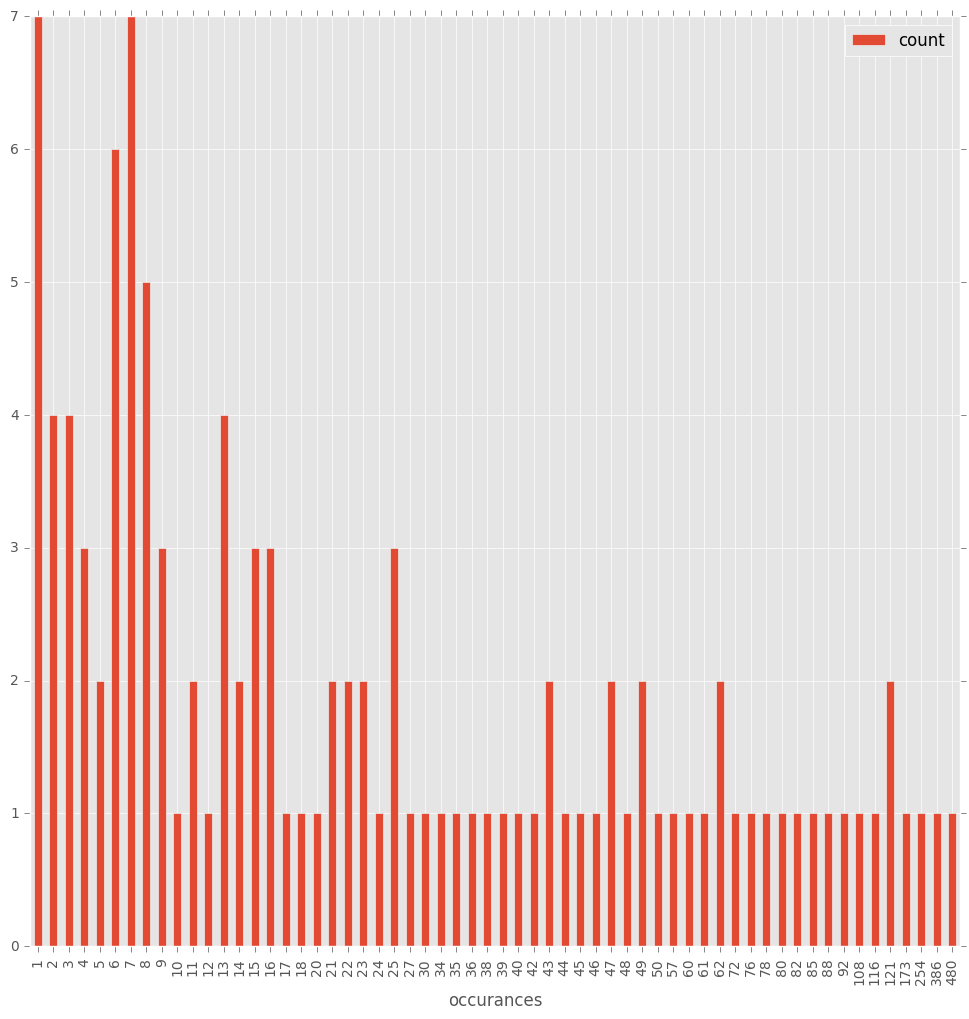

```python
group.plot(kind = 'bar', y = 'count')
```

From the grpah above, we see that there were more cases of smaller occurances than larger occurances. The max number of noise complaints is 480, 386 is right after but that only occured one time in one region.

```python
min(areas.occurances), max(areas.occurances)
```

```
(1, 480)
```

```python
minArea = areas[areas.occurances == 1]
```

```python
maxAreas = areas[areas.occurances == 480]
```

```python
minArea = minArea.reset_index()
del minArea['index']
```

```python
maxAreas = maxAreas.reset_index()
del maxAreas['index']
```

```python
minArea
```

|  | Neighborhood | occurances | Lat | Lon |
| --- | --- | --- | --- | --- |
| 0 | Balboa Terrace | 1 | 37.731599 | -122.463938 |
| 1 | Candlestick Point SRA | 1 | 37.716298 | -122.388131 |
| 2 | India Basin | 1 | 37.733627 | -122.378361 |
| 3 | Laguna Honda | 1 | 37.747639 | -122.458641 |
| 4 | Lincoln Park / Ft. Miley | 1 | 37.784330 | -122.498916 |
| 5 | St. Francis Wood | 1 | 37.735891 | -122.466476 |
| 6 | Sunnydale | 1 | 37.708415 | -122.416303 |

```python
maxAreas
```

|  | Neighborhood | occurances | Lat | Lon |
| --- | --- | --- | --- | --- |
| 0 | South of Market | 480 | 37.781046 | -122.409397 |

From here we see that there are 7 neighborhoods that have the smallest noise complaints. Those areas are Balboa terrace, candlestick point, india basin, laguna honda, lincoln park, st francis wood, sunnydale. The area with the msot noise complaints is in south of market. We will now plot these locations to see if the neighborhoods with little noise complaints are far from the one with the most.

```python
import shapely.geometry as geom
import geopandas as gpd
```

```python
lonlat = [geom.Point(lon, lat) for lon, lat in zip(minArea.Lon, minArea.Lat)]
areas.drop(["Lon", "Lat"], axis = 1)

areas = gpd.GeoDataFrame(minArea, geometry = lonlat, crs = {'init' :'epsg:4326'})
areas.geometry.head()
```

```
0      POINT (-122.463938474175 37.731598603694)
1    POINT (-122.388130559067 37.71629808383071)
2      POINT (-122.378361489645 37.733626733232)
3      POINT (-122.458640998954 37.747639025578)
4      POINT (-122.498916234597 37.784330141308)
Name: geometry, dtype: object
```

```python
lonlat = [geom.Point(lon, lat) for lon, lat in zip(maxAreas.Lon, maxAreas.Lat)]
maxAreas.drop(["Lon", "Lat"], axis = 1)
maxAreas = gpd.GeoDataFrame(maxAreas, geometry = lonlat, crs = {'init' :'epsg:4326'})
maxAreas.geometry.head()
```

```
0    POINT (-122.409397210188 37.781046453006)
Name: geometry, dtype: object
```

```python
sf = gpd.read_file("sf/geo_export_c9c00fb7-1521-4238-9257-b6176bf1cd62.shp")
sf.head()
```

|  | geometry | link | name |
| --- | --- | --- | --- |
| 0 | POLYGON ((-122.4934552679999 37.78351817100008... | http://en.wikipedia.org/wiki/Sea_Cliff,_San_Fr... | Seacliff |
| 1 | POLYGON ((-122.4871507149999 37.78378542700005... | None | Lake Street |
| 2 | POLYGON ((-122.4775801709999 37.81099311300005... | http://www.nps.gov/prsf/index.htm | Presidio National Park |
| 3 | POLYGON ((-122.4724105299999 37.78734653900005... | None | Presidio Terrace |
| 4 | POLYGON ((-122.4726257899999 37.78631480600006... | http://www.sfgate.com/neighborhoods/sf/innerri... | Inner Richmond |

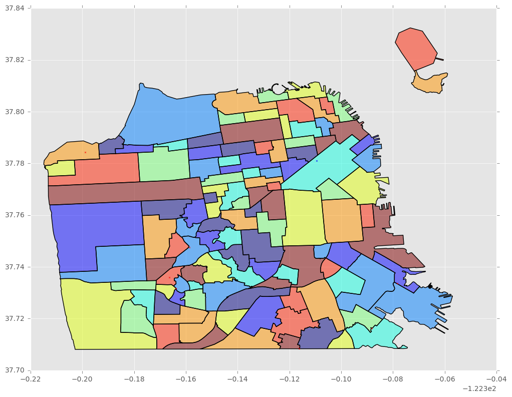

```python
base = sf.plot()
areas.plot(ax = base, marker = "x", color = "red")
maxAreas.plot(ax = base, marker = "x", color = "blue")
```

Although the size of the dots are small (sorry couldn't figure out how to increase the size :(), we can see that the areas with the least noise complaints (dots in red) are quite far from the area with the most noise complaints (dot in blue). But overall, all the areas are quite far from each other.

### Question 4

Are noise complaints and school locations related?

```python
schools = pd.read_sql_query("select * from schools",conn2)
```

```python
schoolsGroup = pd.read_sql_query("select GradeRange, count(GradeRange) as count from schools group by GradeRange",conn2)
```

```python
schoolsGroup
```

|  | GradeRange | count |
| --- | --- | --- |
| 0 | 1-4 | 1 |
| 1 | 1-6 | 1 |
| 2 | 1-8 | 1 |
| 3 | 13-14 | 10 |
| 4 | 2-12 | 1 |
| 5 | 3-8 | 2 |
| 6 | 4-8 | 1 |
| 7 | 5-12 | 1 |
| 8 | 5-8 | 1 |
| 9 | 6-12 | 6 |
| 10 | 6-8 | 16 |
| 11 | 7-12 | 2 |
| 12 | 8-12 | 4 |
| 13 | 9-12 | 36 |
| 14 | INF | 3 |
| 15 | K-1 | 1 |
| 16 | K-12 | 11 |
| 17 | K-2 | 1 |
| 18 | K-4 | 1 |
| 19 | K-5 | 51 |
| 20 | K-6 | 2 |
| 21 | K-8 | 65 |
| 22 | PK | 165 |
| 23 | PK-12 | 1 |
| 24 | PK-4 | 6 |
| 25 | PK-5 | 26 |
| 26 | PK-6 | 1 |
| 27 | PK-8 | 8 |
| 28 | PK-K | 13 |
| 29 | PK-TK | 2 |
| 30 | TK-2 | 2 |
| 31 | TK-8 | 3 |

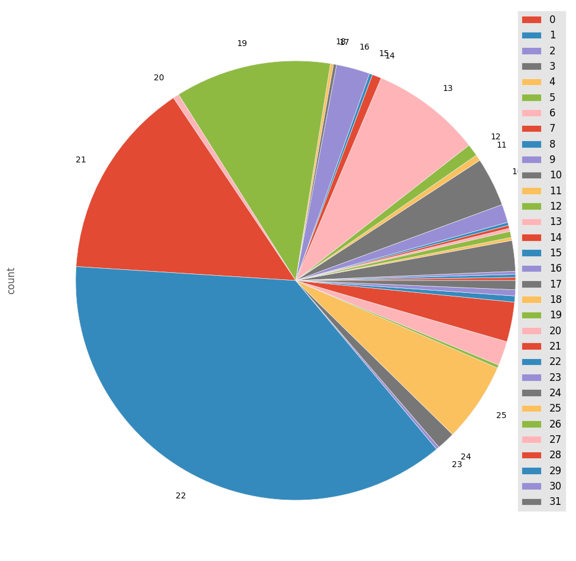

```python
schoolsGroup.plot(kind = 'pie', y = 'count')
```

```python
max(schoolsGroup['count'])
```

```
165
```

```python
schoolsGroup[schoolsGroup['count'] == 165]
```

|  | GradeRange | count |
| --- | --- | --- |
| 22 | PK | 165 |

```python
noise = pd.read_sql_query("select * from noise",conn2)
```

```python
noise = noise.dropna()
```

```python
lonlat = [geom.Point(lon, lat) for lon, lat in zip(schools.Lon, schools.Lat)]

s = gpd.GeoDataFrame(schools, geometry = lonlat, crs = {'init' :'epsg:4326'})
s.geometry.head()
```

```
0    POINT (-122.4822998 37.78300479999999)
1           POINT (-122.4381943 37.7536812)
2           POINT (-122.4657822 37.7296715)
3           POINT (-122.4740601 37.7739677)
4           POINT (-122.4763107 37.7753067)
Name: geometry, dtype: object
```

```python
lonlat = [geom.Point(lon, lat) for lon, lat in zip(noise.Lon, noise.Lat)]

n = gpd.GeoDataFrame(noise, geometry = lonlat, crs = {'init' :'epsg:4326'})
n.geometry.head()
```

```
1    POINT (-122.424474850717 37.7691482064722)
2     POINT (-122.508365256702 37.762047023755)
3     POINT (-122.414943216196 37.787982901643)
4      POINT (-122.502232253358 37.76138549134)
5     POINT (-122.420087435923 37.742435250569)
Name: geometry, dtype: object
```

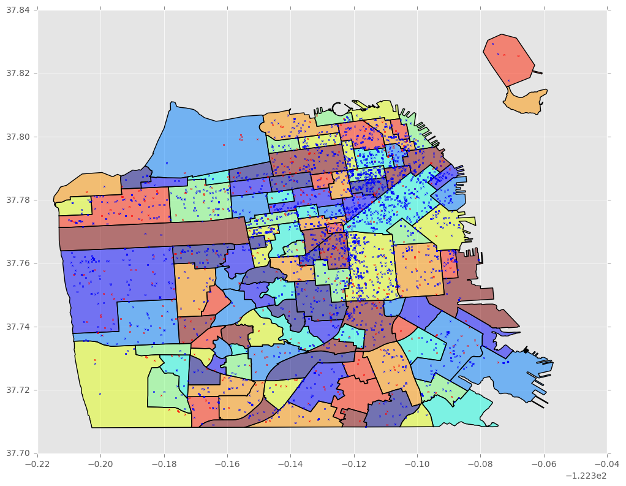

```python
sfp = sf.plot()
s.plot(ax = sfp, marker = "x", color = "red")
n.plot(ax=sfp,marker = "x", color = "blue")
```

Since there are so many datapoints it is hard to tell if there is a correlation. Now, I will separate noise to be during time of school (8 - 3 PM - I'm thinking of only elementary, middle, high school)

```python
noise = pd.read_sql_query("select Datetime, Lat, Lon from noise",conn2)
```

```python
noise = noise.dropna()
```

```python
noise = noise.reset_index()
```

```python
del noise['index']
```

```python
hour = []
for i in range(0, len(noise)):
    date = noise.Datetime[i].split(" ")[1]
    date = datetime.strptime(date, '%H:%M:%S')
    hour.append(date.hour)
```

```python
from collections import defaultdict
d = defaultdict(int)
for i in hour:
    d[i] += 1
result = max(d.iteritems(), key=lambda x: x[1])
print result
```

```
(23, 354)
```

```python
noise['hour'] = hour
```

```python
g8 = noise.where(noise['hour']>=8)
```

```python
g8 = g8.dropna()
```

```python
l15 = noise.where(noise['hour']<=15)
```

```python
l15 = l15.dropna()
```

```python
newNoise = pd.merge(g8, l15)
```

```python
lonlat = [geom.Point(lon, lat) for lon, lat in zip(newNoise.Lon, newNoise.Lat)]

n = gpd.GeoDataFrame(newNoise, geometry = lonlat, crs = {'init' :'epsg:4326'})
n.geometry.head()
```

```
0    POINT (-122.424474850717 37.7691482064722)
1     POINT (-122.508365256702 37.762047023755)
2      POINT (-122.502232253358 37.76138549134)
3     POINT (-122.418177369469 37.805615941191)
4     POINT (-122.510211620936 37.773766740399)
Name: geometry, dtype: object
```

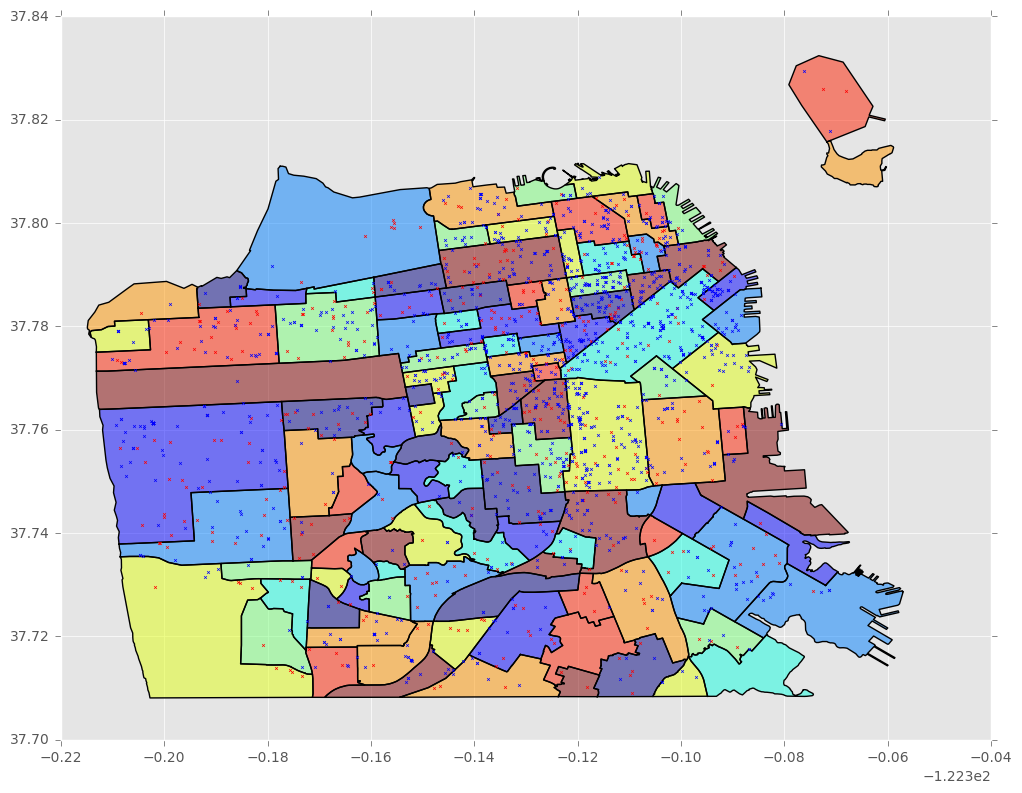

```python
sfp = sf.plot()
s.plot(ax = sfp, marker = "x", color = "red")
n.plot(ax=sfp,marker = "x", color = "blue")
```

It is still fairly difficult to determine whether there is some sort of correlation between noise complaints and school locations, but it does seem like most of the schools are fairly close to where there was a noise complaint. This would make sense because there does tend to be noise complaints in areas where there are kids since kids/younger people are fairly quite loud.

### Question 5

Which type of park is the most popular in San Francisco?

```python
parks = pd.read_sql_query("select Type, count(Type) as occurance, avg(Acreage) from parks group by Type",conn2)
```

```python
parks
```

|  | Type | occurance | avg(Acreage) |
| --- | --- | --- | --- |
| 0 | Civic Plaza or Square | 10 | 4.373000 |
| 1 | Community Garden | 18 | 0.316111 |
| 2 | Concession | 2 | 43.620000 |
| 3 | Family Camp | 1 | 337.510000 |
| 4 | Mini Park | 45 | 0.276000 |
| 5 | Neighborhood Park or Playground | 131 | 4.422748 |
| 6 | Parkway | 2 | 20.740000 |
| 7 | Regional Park | 19 | 155.626842 |
| 8 | Zoological Garden | 1 | 131.520000 |

From here we see that there are more Neighborhood parks/playgrounds more than any other type of park in San Francisco. These neighborhood parks are around 4.4 acres on average. This will be displayed visually in the graph below.

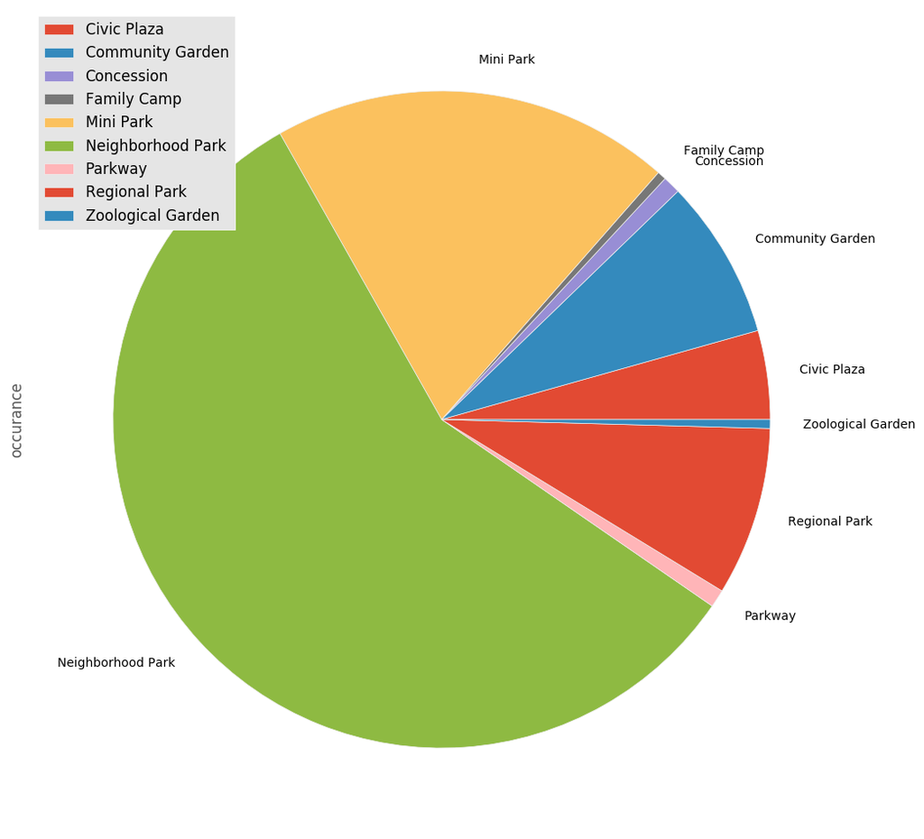

```python
parks.plot(kind = 'pie', y = 'occurance', labels = ['Civic Plaza', 'Community Garden', 'Concession', 'Family Camp', 'Mini Park', 'Neighborhood Park', 'Parkway', 'Regional Park', 'Zoological Garden'])
```